# Getting to know your incomplete data

## Preface

### R packages

In this practical, a number of R packages are used. If any of them are not installed you can still follow the practical but will not be able to run all of the code. The packages used (with versions that were used to generate the solutions) are:

- `mice` (version: 3.3.0)
- `visdat` (version: 0.5.2)
- `JointAI` (version: 0.4.0.9000)
- `VIM` (version: 4.7.0)
- `plyr` (version: 1.8.4)

### Help files

You can find help files for any function by adding a `?` before the name of the function.

Alternatively, you can look up the help pages online at https://www.rdocumentation.org/ or find the whole manual for a package at https://cran.r-project.org/web/packages/available_packages_by_name.html

## Dataset

### Overview

For this example, we will use the **NHANES** dataset. To load this dataset, you can use the command `file.choose()` which opens the explorer and allows you to navigate to the location of the file `NHANES_for_practicals.RData` on your computer. If you know the path to the file, you can also use `load("<path>/NHANES_for_practicals.RData")`.

#### Task

Let’s take a first look at the data. Useful functions are `dim()`, `head()`, `str()` and `summary()`.

#### Solution

```r
dim(NHANES)
```

```
## [1] 1000   24
```

```r
head(NHANES)
```

|  | occup | BMI | HDL | hypchol | hypten | SBP | bili | educ | HyperMed | creat | cohort | age | DBP | smoke | wgt | alc | WC | hgt | race | chol | uricacid | DM | gender | albu |
| --- | --- | --- | --- | --- | --- | --- | --- | --- | --- | --- | --- | --- | --- | --- | --- | --- | --- | --- | --- | --- | --- | --- | --- | --- |
| 836 | looking for work | 22.46495 | NA | NA | no | 131.3333 | NA | High school graduate | NA | NA | 2011 | 61 | 74.66667 | former | 61.23497 | 0 | 79.2 | 1.6510 | Mexican American | NA | NA | no | male | NA |
| 285 | not working | 24.40730 | NA | NA | no | 122.6667 | NA | High school graduate | NA | NA | 2011 | 20 | 73.33333 | former | 79.37866 | 3-7 | 89.4 | 1.8034 | other | NA | NA | no | male | NA |
| 2714 | working | 21.91006 | 1.97 | yes | no | 121.3333 | 0.6 | some college | NA | 0.72 | 2011 | 40 | 77.33333 | current | 81.64663 | >7 | 89.4 | 1.9304 | Non-Hispanic White | 6.34 | 5.8 | no | male | 4.4 |
| 2309 | working | 27.36863 | 1.14 | no | no | 122.0000 | 0.9 | 9-11th grade | NA | 0.97 | 2011 | 24 | 80.00000 | former | 81.64663 | >7 | 92.8 | 1.7272 | Mexican American | 3.96 | 6.3 | no | male | 4.8 |
| 1175 | working | 30.17858 | NA | NA | no | 125.3333 | NA | College or above | NA | NA | 2011 | 61 | 82.66667 | never | 74.84274 | 1-3 | 105.2 | 1.5748 | Other Hispanic | NA | NA | no | female | NA |
| 751 | not working | 30.99756 | NA | NA | yes | 136.6667 | NA | High school graduate | no | NA | 2011 | 61 | 81.33333 | current | 112.49091 | 1-3 | NA | 1.9050 | Non-Hispanic Black | NA | NA | no | male | NA |

```r
str(NHANES)
```

```
## 'data.frame':    1000 obs. of  24 variables:
##  $ occup   : Factor w/ 3 levels "working","looking for work",..: 2 3 1 1 1 3 1 1 3 1 ...
##  $ BMI     : num  22.5 24.4 21.9 27.4 30.2 ...
##  $ HDL     : num  NA NA 1.97 1.14 NA NA 1.32 1.6 1.14 2.2 ...
##  $ hypchol : Factor w/ 2 levels "no","yes": NA NA 2 1 NA NA 1 1 1 1 ...
##  $ hypten  : Factor w/ 2 levels "no","yes": 1 1 1 1 1 2 NA 1 2 1 ...
##  $ SBP     : num  131 123 121 122 125 ...
##  $ bili    : num  NA NA 0.6 0.9 NA NA 1.1 0.5 0.6 0.8 ...
##  $ educ    : Factor w/ 5 levels "Less than 9th grade",..: 3 3 4 2 5 3 2 5 3 3 ...
##  $ HyperMed: Ord.factor w/ 3 levels "no"<"previous"<..: NA NA NA NA NA 1 NA NA 2 NA ...
##  $ creat   : num  NA NA 0.72 0.97 NA NA 0.72 0.64 0.9 0.45 ...
##  $ cohort  : chr  "2011" "2011" "2011" "2011" ...
##  $ age     : num  61 20 40 24 61 61 61 38 40 51 ...
##  $ DBP     : num  74.7 73.3 77.3 80 82.7 ...
##  $ smoke   : Ord.factor w/ 3 levels "never"<"former"<..: 2 2 3 2 1 3 2 1 1 1 ...
##  $ wgt     : num  61.2 79.4 81.6 81.6 74.8 ...
##  $ alc     : Ord.factor w/ 5 levels "0"<"<=1"<"1-3"<..: 1 4 5 5 3 3 3 3 2 NA ...
##  $ WC      : num  79.2 89.4 89.4 92.8 105.2 ...
##  $ hgt     : num  1.65 1.8 1.93 1.73 1.57 ...
##  $ race    : Factor w/ 5 levels "Mexican American",..: 1 5 3 1 2 4 5 4 3 5 ...
##  $ chol    : num  NA NA 6.34 3.96 NA NA 4.09 5.9 4.53 5.4 ...
##  $ uricacid: num  NA NA 5.8 6.3 NA NA 5.8 4.9 4.5 3.3 ...
##  $ DM      : Factor w/ 2 levels "no","yes": 1 1 1 1 1 1 1 2 1 1 ...
##  $ gender  : Factor w/ 2 levels "male","female": 1 1 1 1 2 1 1 2 1 2 ...
##  $ albu    : num  NA NA 4.4 4.8 NA NA 4.8 4.2 4.1 4.6 ...
```

```r
summary(NHANES)
```

```
##               occup          BMI                HDL        hypchol     hypten         SBP
##  working         :555   Min.   :   0.001   Min.   :0.360   no  :806   no  :625   Min.   : 84.0
##  looking for work: 45   1st Qu.:  23.436   1st Qu.:1.110   yes :108   yes :346   1st Qu.:109.3
##  not working     :387   Median :  26.940   Median :1.320   NA's: 86   NA's: 29   Median :118.7
##  NA's            : 13   Mean   :  32.278   Mean   :1.389                         Mean   :120.9
##                         3rd Qu.:  30.999   3rd Qu.:1.600                         3rd Qu.:130.7
##                         Max.   :1828.822   Max.   :3.130                         Max.   :187.3
##                         NA's   :6          NA's   :86                            NA's   :45
##       bili                          educ         HyperMed       creat           cohort
##  Min.   :0.2000   Less than 9th grade : 74   no      : 45   Min.   :0.3400   Length:1000
##  1st Qu.:0.6000   9-11th grade        :142   previous: 26   1st Qu.:0.6950   Class :character
##  Median :0.7000   High school graduate:220   yes     :211   Median :0.8200   Mode  :character
##  Mean   :0.7473   some college        :296   NA's    :718   Mean   :0.8639
##  3rd Qu.:0.9000   College or above    :267                  3rd Qu.:0.9650
##  Max.   :4.1000   NA's                :  1                  Max.   :7.4600
##  NA's   :89                                                 NA's   :89
##       age             DBP             smoke          wgt            alc            WC
##  Min.   :20.00   Min.   : 12.67   never  :567   Min.   :  38.55   0   :133   Min.   : 61.90
##  1st Qu.:32.00   1st Qu.: 64.00   former :207   1st Qu.:  63.50   <=1 :277   1st Qu.: 85.20
##  Median :45.00   Median : 70.67   current:225   Median :  77.11   1-3 :114   Median : 96.20
##  Mean   :46.21   Mean   : 70.77   NA's   :  1   Mean   : 109.13   3-7 : 94   Mean   : 96.97
##  3rd Qu.:60.00   3rd Qu.: 78.00                 3rd Qu.:  90.72   >7  :110   3rd Qu.:106.40
##  Max.   :79.00   Max.   :114.00                 Max.   :4535.47   NA's:272   Max.   :163.50
##                  NA's   :45                     NA's   :1                    NA's   :47
##       hgt                          race          chol           uricacid        DM
##  Min.   :  1.397   Mexican American  :103   Min.   : 2.070   Min.   : 1.800   no :843
##  1st Qu.:  1.600   Other Hispanic    :108   1st Qu.: 4.340   1st Qu.: 4.400   yes:157
##  Median :  1.676   Non-Hispanic White:351   Median : 5.005   Median : 5.300
##  Mean   :  3.711   Non-Hispanic Black:245   Mean   : 5.045   Mean   : 5.422
##  3rd Qu.:  1.753   other             :193   3rd Qu.: 5.610   3rd Qu.: 6.300
##  Max.   :253.975                            Max.   :10.060   Max.   :11.200
##  NA's   :5                                  NA's   :86       NA's   :89
##     gender         albu
##  male  :482   Min.   :2.600
##  female:518   1st Qu.:4.100
##               Median :4.300
##               Mean   :4.271
##               3rd Qu.:4.500
##               Max.   :5.200
##               NA's   :89
```

### Variable coding

It is important to check that all variables are coded correctly, i.e., have the correct `class`. Imputation software (e.g., the **mice** package) uses the `class` to automatically select imputation methods. When importing data from other software it can happen that factors become continuous variables or that ordered factors lose their ordering.

`str()` showed that in the NHANES data `smoke` and `alc` are correctly specified as ordinal variables, but `educ` is an unordered factor.

#### Task

Using `levels(NHANES$educ)` we can print the names of the categories of `educ`. Convert the unordered factor to an ordered factor, for example using `as.ordered()`. Afterwards, check if the conversion was successful.

#### Solution

```r
levels(NHANES$educ)
```

```
## [1] "Less than 9th grade"  "9-11th grade"         "High school graduate" "some college"
## [5] "College or above"
```

```r
NHANES$educ <- as.ordered(NHANES$educ)

str(NHANES$educ)
```

```
##  Ord.factor w/ 5 levels "Less than 9th grade"<..: 3 3 4 2 5 3 2 5 3 3 ...
```

## Distribution of missing values

### Missing data pattern

In the `summary()` we could already see that there are missing values in several variables. The missing data pattern can be obtained and visualized by several functions from different packages. Examples are

- `md.pattern()` from package **mice**
- `md_pattern()` from package **JointAI** (with argument `patter = TRUE`)
- `aggr()` from package **VIM**
- `vis_dat()` and `vis_miss()` from package **visdat**

#### Task

Explore the missing data pattern of the NHANES data.

#### Solution (i)

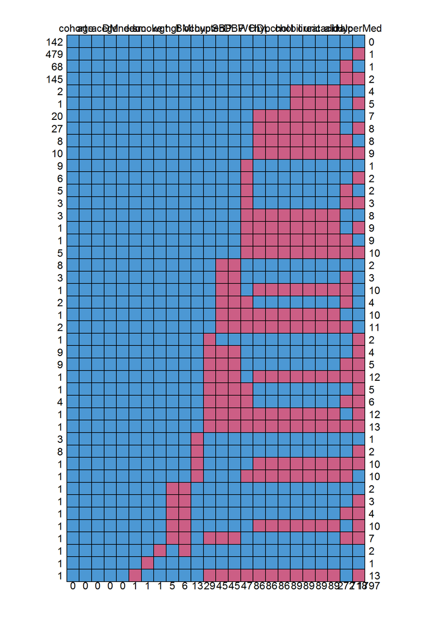

```r
mdp <- mice::md.pattern(NHANES)
```

```r
mdp
```

```
##     cohort age race DM gender educ smoke wgt hgt BMI occup hypten SBP DBP WC HDL hypchol chol bili
## 142      1   1    1  1      1    1     1   1   1   1     1      1   1   1  1   1       1    1    1
## 479      1   1    1  1      1    1     1   1   1   1     1      1   1   1  1   1       1    1    1
## 68       1   1    1  1      1    1     1   1   1   1     1      1   1   1  1   1       1    1    1
## 145      1   1    1  1      1    1     1   1   1   1     1      1   1   1  1   1       1    1    1
## 2        1   1    1  1      1    1     1   1   1   1     1      1   1   1  1   1       1    1    0
## 1        1   1    1  1      1    1     1   1   1   1     1      1   1   1  1   1       1    1    0
## 20       1   1    1  1      1    1     1   1   1   1     1      1   1   1  1   0       0    0    0
## 27       1   1    1  1      1    1     1   1   1   1     1      1   1   1  1   0       0    0    0
## 8        1   1    1  1      1    1     1   1   1   1     1      1   1   1  1   0       0    0    0
## 10       1   1    1  1      1    1     1   1   1   1     1      1   1   1  1   0       0    0    0
## 9        1   1    1  1      1    1     1   1   1   1     1      1   1   1  0   1       1    1    1
## 6        1   1    1  1      1    1     1   1   1   1     1      1   1   1  0   1       1    1    1
## 5        1   1    1  1      1    1     1   1   1   1     1      1   1   1  0   1       1    1    1
## 3        1   1    1  1      1    1     1   1   1   1     1      1   1   1  0   1       1    1    1
```

[output cut: 77 more lines]

`md.pattern()` from package **mice** gives us a matrix where each row represents one missing data pattern (1 = observed, 0 = missing). The rownames show how many rows of the dataset have the given pattern. The last column shows the number of missing values in each pattern, the last row the number of missing values per variable.

`md.pattern()` also plots the missing data pattern automatically.

#### Solution (ii)

```r
MDP <- JointAI::md_pattern(NHANES, pattern = TRUE)
```

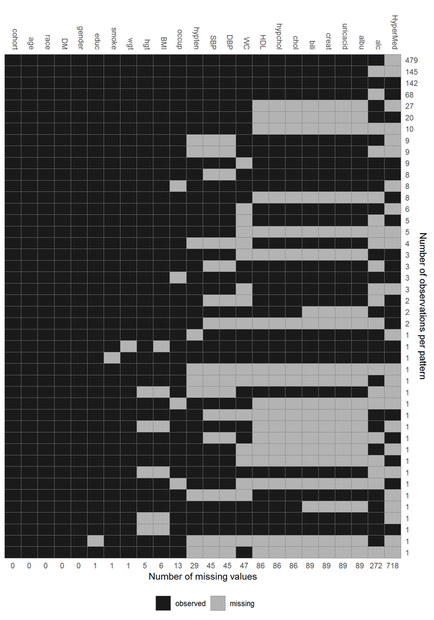

```r
MDP
```

```
##      cohort age race DM gender educ smoke wgt hgt BMI occup hypten SBP DBP WC HDL hypchol chol bili
## 1         1   1    1  1      1    1     1   1   1   1     1      1   1   1  1   1       1    1    1
## 2         1   1    1  1      1    1     1   1   1   1     1      1   1   1  1   1       1    1    1
## 3         1   1    1  1      1    1     1   1   1   1     1      1   1   1  1   1       1    1    1
## 4         1   1    1  1      1    1     1   1   1   1     1      1   1   1  1   1       1    1    1
## 5         1   1    1  1      1    1     1   1   1   1     1      1   1   1  1   0       0    0    0
## 6         1   1    1  1      1    1     1   1   1   1     1      1   1   1  1   0       0    0    0
## 7         1   1    1  1      1    1     1   1   1   1     1      1   1   1  1   0       0    0    0
## 8         1   1    1  1      1    1     1   1   1   1     1      0   0   0  1   1       1    1    1
## 9         1   1    1  1      1    1     1   1   1   1     1      0   0   0  1   1       1    1    1
## 10        1   1    1  1      1    1     1   1   1   1     1      1   1   1  0   1       1    1    1
## 11        1   1    1  1      1    1     1   1   1   1     1      1   0   0  1   1       1    1    1
## 12        1   1    1  1      1    1     1   1   1   1     0      1   1   1  1   1       1    1    1
## 13        1   1    1  1      1    1     1   1   1   1     1      1   1   1  1   0       0    0    0
## 14        1   1    1  1      1    1     1   1   1   1     1      1   1   1  0   1       1    1    1
```

[output cut: 77 more lines]

The function `md_pattern()` from package **JointAI** gives a matrix very similar to the one obtained from `mice::md.pattern()`. Hovever, here, the number of rows in the data that have a particular missing data pattern are given in the last column.

For more information on how to customize the visualization by `md_pattern()` see the vignette [Visualizing Incomplete Data](https://nerler.github.io/JointAI/articles/VisualizingIncompleteData.html) on the [webpage of **JointAI**](https://nerler.github.io/JointAI/index.html).

#### Solution (iii)

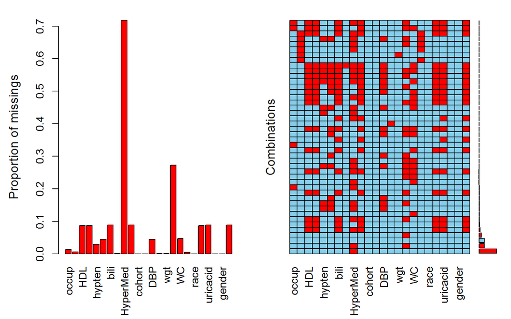

```r
VIM::aggr(NHANES)
```

`aggr()` from **VIM** plots a histogram of the proportion of missing values per column as well as a visualization of the missing data pattern. Here, a small histogram on the right edge of the plot shows the proportion of cases in each pattern.

For more options how to customize the plot, see the [**VIM** documentation](https://CRAN.R-project.org/package=VIM).

### Proportion of missing values

#### Task

Now get an overview of

- how much missingness there is in each variable, and
- the proportion of (in)complete cases.

The function `complete.cases()` will give you a vector that is TRUE if the the case is complete and FALSE if there are missing values.

`is.na()` returns `TRUE` if the value is missing, `FALSE` if the value is observed

`colSums()` calculates the sum of values in each column of a data.frame or matrix

`colMeans()` calculates the mean of values in each column of a data.frame or matrix

#### Solution

```r
# number and proportion of complete cases
cbind(
  "#" = table(ifelse(complete.cases(NHANES), 'complete', 'incomplete')),
  "%" = round(100 * table(complete.cases(NHANES))/nrow(NHANES), 2)
)
```

```
##              #    %
## complete   142 85.8
## incomplete 858 14.2
```

```r
# number and proportion of missing values per variable
cbind("# NA" = sort(colSums(is.na(NHANES))),
      "% NA" = round(sort(colMeans(is.na(NHANES))) * 100, 2))
```

```
##          # NA % NA
## cohort      0  0.0
## age         0  0.0
## race        0  0.0
## DM          0  0.0
## gender      0  0.0
## educ        1  0.1
## smoke       1  0.1
## wgt         1  0.1
## hgt         5  0.5
## BMI         6  0.6
## occup      13  1.3
## hypten     29  2.9
## SBP        45  4.5
## DBP        45  4.5
## WC         47  4.7
## HDL        86  8.6
## hypchol    86  8.6
## chol       86  8.6
## bili       89  8.9
## creat      89  8.9
## uricacid   89  8.9
## albu       89  8.9
## alc       272 27.2
## HyperMed  718 71.8
```

### Relationship between variables

In the missing data pattern we could already see that some variables tend to be missing together. But there may be different types of relationships between variables that are of interest.

#### Task 1

Our data contains `hgt` (height), `wgt` (weight) and `BMI`. Check the missing data pattern specifically for those three variables.

#### Solution 1

```r
# Three solutions to choose from:
JointAI::md_pattern(NHANES[, c("hgt", "wgt", "BMI")], pattern = TRUE, plot = FALSE)
```

```
##      wgt hgt BMI Npat
## 1      1   1   1  994
## 2      1   0   0    5
## 3      0   1   0    1
## Nmis   1   5   6   12
```

```r
with(NHANES,
     table(ifelse(is.na(hgt), 'height mis.', 'height obs.'),
           ifelse(is.na(wgt), 'weight mis.', 'weight obs.'),
           ifelse(is.na(BMI), 'BMI mis.', 'BMI obs.'))
)
```

```
## , ,  = BMI mis.
##
##
##               weight mis. weight obs.
##   height mis.           0           5
##   height obs.           1           0
##
## , ,  = BMI obs.
##
##
##               weight mis. weight obs.
##   height mis.           0           0
##   height obs.           0         994
```

```r
plyr::ddply(NHANES, c(height = "ifelse(is.na(hgt), 'missing', 'observed')",
                      weight = "ifelse(is.na(wgt), 'missing', 'observed')",
                      BMI = "ifelse(is.na(BMI), 'missing', 'observed')"),
            plyr::summarize,
            N = length(hgt)
)
```

| height | weight | BMI | N |
| --- | --- | --- | --- |
| missing | observed | missing | 5 |
| observed | missing | missing | 1 |
| observed | observed | observed | 994 |

As we have already seen in the lecture, there are some cases where only either `hgt` or `wgt` is missing. `BMI` is only observed when both components are observed. To use all available information, we want to impute `hgt` and `wgt` separately and calculate `BMI` from the imputed values.

#### Task 2

The data contains variables on hypertension (`hypten`) and the use of medication to treat hypertension (`HyperMed`). We might expect that medication is only prescribed for patients with hypertension, hence, we need to investigate the relationship between `HyperMed` and `hypten`.

- Make a table of the two variables to confirm our expectation.
- Make sure that missing values are also displayed in that table!

#### Solution 2

```r
with(NHANES, table(HyperMed, hypten, exclude = NULL))
```

```
##           hypten
## HyperMed    no yes <NA>
##   no         0  45    0
##   previous   0  26    0
##   yes        0 211    0
##   <NA>     625  64   29
```

#### Task 3

Furthermore, we can expect a systematic relationship between the variables `hypchol` (Hypercholesterolemia) and `chol` (serum cholesterol). Find out how these two variables are related.

#### Solution 3

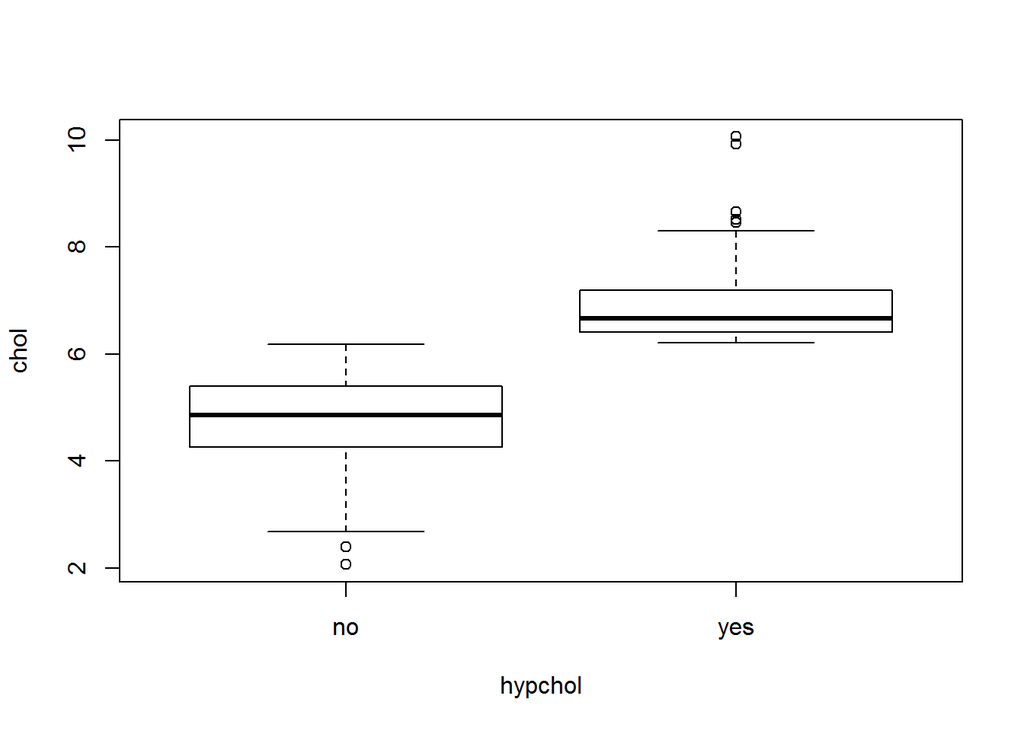

```r
with(NHANES, plot(chol ~ hypchol))
```

```r
with(NHANES, summary(chol[hypchol == "no"]))
```

```
##    Min. 1st Qu.  Median    Mean 3rd Qu.    Max.    NA's
##   2.070   4.270   4.860   4.796   5.400   6.180      86
```

```r
with(NHANES, summary(chol[hypchol == "yes"]))
```

```
##    Min. 1st Qu.  Median    Mean 3rd Qu.    Max.    NA's
##   6.210   6.410   6.660   6.903   7.190  10.060      86
```

It seems that `hypchol` is defined as `chol > 6.2`, which makes `hypchol` dependent on `chol`.

## Distribution of the data

Before imputing missing values it is important to take a look at how the observed parts of incomplete variables are distributed, so that we can choose appropriate imputation models.

### Task

Visualize the distributions of the incomplete continuous and categorical variables. The package **JointAI** provides the convenient function `plot_all()`,

Pay attention to

- whether continuous distributions deviate considerably from the normal distribution,
- if variables have values close to the limits of the range they are defined in,
- whether categorical variables are very unbalanced (i.e., some category very small).

### Solution

```r
par(mar = c(3, 3, 2, 1), mgp = c(2, 0.6, 0))
JointAI::plot_all(NHANES, nclass = 30, ncol = 4)
```

[figure not shown]

To learn more about additional options of `plot_all()` check out the vignette [Visualizing Incomplete Data](https://nerler.github.io/JointAI/articles/VisualizingIncompleteData.html) on the [webpage of **JointAI**](https://nerler.github.io/JointAI/index.html).